# Settlement Agreement Derivation Analysis

# Background

Outstanding Florida Water (OFW) baseline limits were developed for Everglades National Park and Loxahatchee National Wildlife Refuge. This document is *NOT* a reanalysis but rather documentation of how the analysis was performed. Unlike the original analysis, this analysis is performed in base [R](https://cran.r-project.org/) which *should* result in simlar if not identical values. All information related to these analyses including relevant background can be found in Appendix E of the Everglades Surface Water Improvement and Management Plan ([link](https://www.sfwmd.gov/document/1992-surface-water-improvement-and-management-swim-plan-everglades-planning-document)).

## Appendix A

The basic regression model is expressed as a formula,

$$[TP] = a + b \times T + c \times Q + e$$

where T (Federal Water Year) ranges from 78 to 90 (excluding 85 and 86) and Q (flow) ranges from 116.860 to 1061.258 x10<sup>3</sup> Ac-Ft Yr<sup>-1</sup>. The $a$, $b$ and $c$ appear in the formula represening unknown coefficients which are to be estimated from the period of record data in a manner which forces the model to provide a “best fit” to the available data. The model term $e$ in the formula represents the difference between a model prediction for $[TP]$ and the value of $[TP]$ actually observed for a water year in question.

For more detail in the specifics of the analysis please refer to Appenidx E of the SWIM Plan.

### SRS Interim Limit Derivation

Data:

- Discharge: S12s + S333 Composite Annual discharge
- Water Quality (TP): S12s + S333 Flow-weighted mean
- Outliers:
  - 1 outlier deleted in 1980
  - Data from WY 1985 and 1986 were excluded from the analysis.

**Table 1:** Calculation of interim limits for Shark River Slough with 10% rejection limit on annual mean Total Phosphorous concentrations. Table includes Detrended and adjusted TP for annual total flow to Everglades National Park.

| Variables Water Year | T Year | 10<sup>3</sup> Ac-Ft Y<sup>-1</sup> Q Flow | µg L<sup>-1</sup> Y TP FWM | µg L<sup>-1</sup> Y<sub>m</sub> Predicted | µg L<sup>-1</sup> Y<sub>Q</sub> Flow-Adjusted | µg L<sup>-1</sup> Y<sub>T</sub> De-Trend | µg L<sup>-1</sup> Target 50% Target | µg L<sup>-1</sup> 90% Limit Upper Limit | µg L<sup>-1</sup> 90% Limit Lower Limit |
| --- | --- | --- | --- | --- | --- | --- | --- | --- | --- |
| 1978 | 78 | 522.803 | 6.72 | 8.4 | 6.71 | 7.02 | 8.72 | 11.68 | 5.77 |
| 1979 | 79 | 407.050 | 9.79 | 9.6 | 9.25 | 9.49 | 9.26 | 12.29 | 6.23 |
| 1980 | 80 | 649.164 | 10.63 | 9.0 | 11.21 | 9.74 | 8.14 | 11.06 | 5.21 |
| 1981 | 81 | 291.687 | 12.44 | 11.3 | 11.36 | 10.96 | 9.80 | 12.93 | 6.67 |
| 1982 | 82 | 861.328 | 8.42 | 9.2 | 9.99 | 6.34 | 7.15 | 10.12 | 4.18 |
| 1983 | 83 | 1061.258 | 7.04 | 8.9 | 9.54 | 4.37 | 6.22 | 9.35 | 3.09 |
| 1984 | 84 | 842.779 | 11.97 | 10.5 | 13.45 | 8.71 | 7.24 | 10.20 | 4.28 |
| 1985 | 85 |  |  |  |  |  |  |  |  |
| 1986 | 86 |  |  |  |  |  |  |  |  |
| 1987 | 87 | 276.623 | 15.95 | 14.9 | 14.80 | 10.91 | 9.87 | 13.01 | 6.72 |
| 1988 | 88 | 585.451 | 15.59 | 14.1 | 15.88 | 9.95 | 8.43 | 11.36 | 5.50 |
| 1989 | 89 | 116.860 | 13.53 | 16.8 | 11.64 | 7.30 | 10.61 | 13.96 | 7.26 |
| 1990 | 90 | 148.219 | 18.06 | 17.3 | 16.31 | 11.24 | 10.46 | 13.77 | 7.16 |

From Appendix E

- $Upper Limit = 11.16 - 0.00465\times Q + 1.397\sqrt{6.377-0.00591\times Q + 0.00000436 \times Q^{2}}$

Interim limit constants and variables

| Abbrevation | Definition | Value |
| --- | --- | --- |
| n | Number of Years of Data | 11 |
| dof | Degrees of Freedom | 8 |
| b<sub>1</sub> | Slope of Regression, T-T<sub>m</sub> | 0.59323 |
| b<sub>2</sub> | Slope of Regression, Q-Q<sub>m</sub> | -0.00465 |
| Q<sub>m</sub> | Mean of Annual Flows | 523.93 |
| T<sub>m</sub> | Mean of Years | 83.7 |
| T<sub>OFW</sub> | Mean of OFW Period | 78.5 |
| Y<sub>m</sub> | Mean of Predicted TP | 11.8 |
| Prob | Probability (1-sided) | 0.1 |
| t<sub>dof</sub> | t-Statistic at 90% | 1.397 |
| SE | Standard Residual Error of Regression | 1.873 |
| Var(b<sub>1</sub>) | Variance of Time moment, T-T<sub>m</sub> | 0.023724 |
| Var(b<sub>2</sub>) | Variance of Flow moment, Q-Q<sub>m</sub> | 0.00000436 |
| Cov(b<sub>1</sub>,b<sub>2</sub>) | Covariance of Time and Flow variables | 0.00012886 |

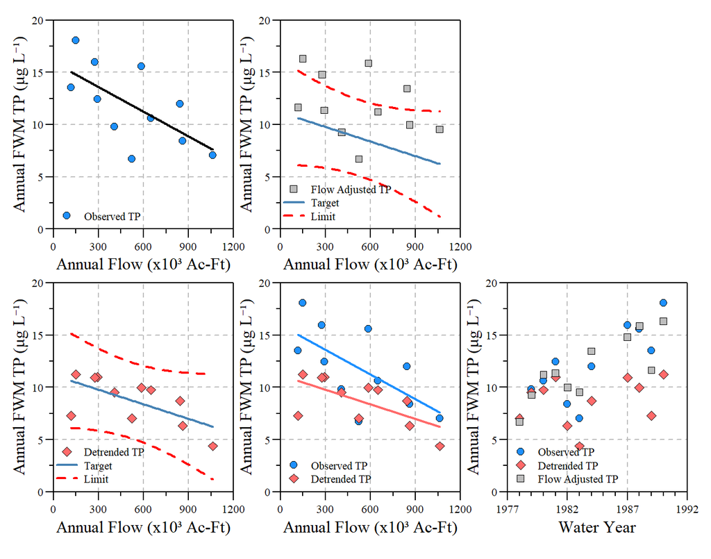

**Figure 1:** Flow-weighted mean total phosphorus concentrations observed during the extended Outstanding Florida Waters baseline period for S12s + S333 .

### SRS Long-Term Limit Derivation

Data:

- Discharge: S12s + S333 Composite Annual discharge
- Water Quality (TP): S12s Flow-weighted mean
- Outliers:
  - 1 outlier deleted in 1980
  - Data from WY 1985 and 1986 were excluded from the analysis.

**Table 2:** Calculation of long-term limits for Shark River Slough with 10% rejection limit on annual mean Total Phosphorous concentrations. Table includes Detrended and adjusted TP for annual total flow to Everglades National Park.

| Variables Water Year | T Year | 10<sup>3</sup> Ac-Ft Y<sup>-1</sup> Q Flow | µg L<sup>-1</sup> Y TP FWM | µg L<sup>-1</sup> Y<sub>m</sub> Predicted | µg L<sup>-1</sup> Y<sub>Q</sub> Flow-Adjusted | µg L<sup>-1</sup> Y<sub>T</sub> De-Trend | µg L<sup>-1</sup> Target 50% Target | µg L<sup>-1</sup> 90% Limit Upper Limit | µg L<sup>-1</sup> 90% Limit Lower Limit |
| --- | --- | --- | --- | --- | --- | --- | --- | --- | --- |
| 1978 | 78 | 522.803 | 6.72 | 8.3 | 6.71 | 6.94 | 8.57 | 10.42 | 6.72 |
| 1979 | 79 | 407.050 | 8.76 | 9.4 | 8.13 | 8.54 | 9.19 | 11.09 | 7.30 |
| 1980 | 80 | 649.164 | 10.47 | 8.6 | 11.14 | 9.80 | 7.89 | 9.72 | 6.06 |
| 1981 | 81 | 291.687 | 12.22 | 10.9 | 10.97 | 11.11 | 9.81 | 11.77 | 7.86 |
| 1982 | 82 | 861.328 | 7.92 | 8.3 | 9.73 | 6.36 | 6.75 | 8.61 | 4.89 |
| 1983 | 83 | 1061.258 | 6.89 | 7.7 | 9.78 | 4.89 | 5.67 | 7.63 | 3.72 |
| 1984 | 84 | 842.779 | 9.83 | 9.3 | 11.55 | 7.38 | 6.85 | 8.70 | 5.00 |
| 1985 | 85 |  |  |  |  |  |  |  |  |
| 1986 | 86 |  |  |  |  |  |  |  |  |
| 1987 | 87 | 276.623 | 14.25 | 13.7 | 12.92 | 10.47 | 9.90 | 11.86 | 7.93 |
| 1988 | 88 | 585.451 | 12.82 | 12.5 | 13.15 | 8.59 | 8.23 | 10.07 | 6.40 |
| 1989 | 89 | 116.860 | 14.42 | 15.4 | 12.23 | 9.75 | 10.75 | 12.85 | 8.66 |
| 1990 | 90 | 148.219 | 15.50 | 15.7 | 13.48 | 10.38 | 10.59 | 12.65 | 8.52 |

From Appendix E

- $Upper Limit = 11.38 - 0.00538\times Q + 1.397\sqrt{2.493-0.00231\times Q + 0.00000170 \times Q^{2}}$

Interim limit constants and variables

| Abbrevation | Definition | Value |
| --- | --- | --- |
| n | Number of Years of Data | 11 |
| dof | Degrees of Freedom | 8 |
| b<sub>1</sub> | Slope of Regression, T-T<sub>m</sub> | 0.44491 |
| b<sub>2</sub> | Slope of Regression, Q-Q<sub>m</sub> | -0.00538 |
| Q<sub>m</sub> | Mean of Annual Flows | 523.93 |
| T<sub>m</sub> | Mean of Years | 83.7 |
| T<sub>OFW</sub> | Mean of OFW Period | 78.5 |
| Y<sub>m</sub> | Mean of Predicted TP | 10.9 |
| Prob | Probability (1-sided) | 0.1 |
| t<sub>dof</sub> | t-Statistic at 90% | 1.397 |
| SE | Standard Residual Error of Regression | 1.1712 |
| Var(b<sub>1</sub>) | Variance of Time moment, T-T<sub>m</sub> | 0.009275 |
| Var(b<sub>2</sub>) | Variance of Flow moment, Q-Q<sub>m</sub> | 0.0000017 |
| Cov(b<sub>1</sub>,b<sub>2</sub>) | Covariance of Time and Flow variables | 0.00005038 |

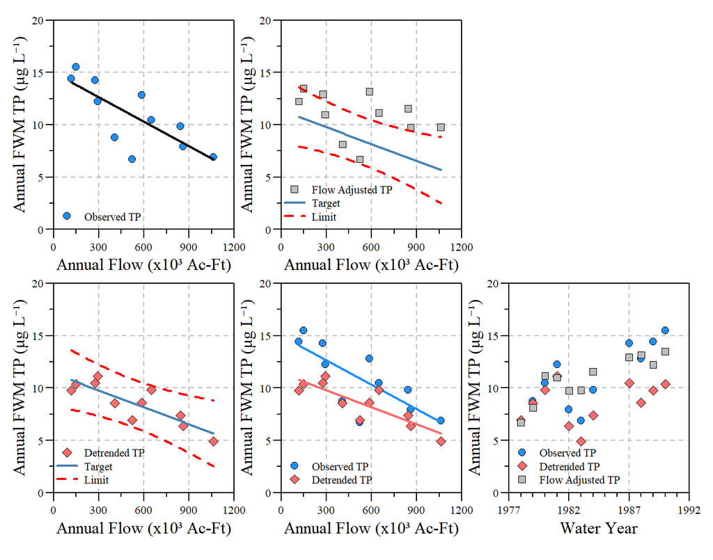

**Figure 2:** Flow-weighted mean total phosphorus concentrations observed during the extended Outstanding Florida Waters baseline period for S12s and composite flow of the S12s + S333 .

### TSCB Limit

Due to limited data with the first WY of sampling occuring in October 1, 1983, the baseline period was limited to Federal WY 1984. As summarized in Appendix E, no significant trend in the annual average TP concentration over the WY1984 - 1990 period was oberserved. Furthermore, no correlation with discharge was apparent.

Data:

- Discharge: S18C + S332 Composite Annual discharge
- Water Quality (TP): S18C + S332 Flow-weighted mean

Total P is log transformed and regressed against “base” indicating the baseline. Model error is simplified to the regression residual error.

- **Regression Mode:** $Ln(Y_{m}) = b_{0} + b_{1}\times base$
- **Adjusted TP:** $Ln(Y_{adj})=b_{0}+b_{1}\times 1$
- **S:** $S = \sqrt{SE^{2} + \frac{S^{2}}{1}}$
- **Upper Limit:** $90\% Limit = Y_{adj} + t_{dof} \times S$

**Table 3:** Calculation of long-term limits for Taylor Slough and Coastal Basins with 10% rejection limit on annual mean Total Phosphorous concentrations.

| Variables Water Year | Variables Year | Baseline | 10<sup>3</sup> Ac-Ft Y<sup>-1</sup> Q Flow | µg L<sup>-1</sup> Y TP FWM | µg L<sup>-1</sup> Y<sub>m</sub> Predicted | µg L<sup>-1</sup> Y<sub>adj</sub> Adjusted | µg L<sup>-1</sup> 90% Limit Upper Limit | µg L<sup>-1</sup> 90% Limit Lower Limit |
| --- | --- | --- | --- | --- | --- | --- | --- | --- |
| 1984 | 84 | 1 |  | 5.8 | 5.8 | 5.8 | 11.1 | 3 |
| 1985 | 85 | 0 |  | 9.5 | 10.1 | 5.8 | 11.1 | 3 |
| 1986 | 86 | 0 |  | 7.5 | 10.1 | 5.8 | 11.1 | 3 |
| 1987 | 87 | 0 |  | 16.0 | 10.1 | 5.8 | 11.1 | 3 |
| 1988 | 88 | 0 |  | 10.3 | 10.1 | 5.8 | 11.1 | 3 |
| 1989 | 89 | 0 |  | 12.6 | 10.1 | 5.8 | 11.1 | 3 |
| 1990 | 90 | 0 |  | 7.1 | 10.1 | 5.8 | 11.1 | 3 |

Note:  
Upper 90% Limit deviates slightly from Appendix E published values presumably due to rounding.

Interim limit constants and variables

[output not shown]

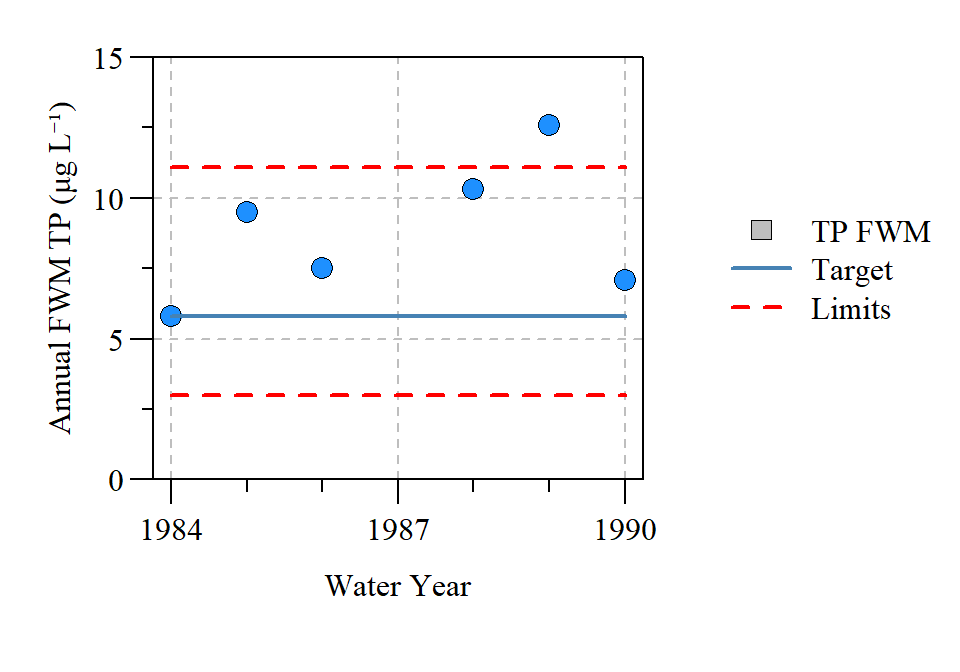

**Figure 3:** Flow-weighted mean total phosphorus concentrations observed during the extended Outstanding Florida Waters baseline period for S18C+S332.